agosto 24, 2021

[Para más estilos de encabezados](https://bookdown.org/yihui/rmarkdown/html-document.html)

# 1 Definiciones generales

## 1.1 ¿Qué es una matriz?

Matriz. Sea $(\mathbb{K},+,.)$ un cuerpo conmutativo y $m,n\ge1$ enteros. Una matriz $m\times n$ sobre $\mathbb{K}$ (o de orden $m\times n$ sobre $\mathbb{K}$) es una tabla formada por elementos de $\mathbb{K}$ dispuestos en $m$ filas y $n$ columnas de la forma

$$\begin{pmatrix}a_{11} & a_{12} & \cdots & a_{1n}\\ a_{21} & a_{22} & \cdots & a_{2n}\\ \vdots & \vdots & \ddots & \vdots\\ a_{m1} & a_{m2} & \cdots & a_{mn}\\ \end{pmatrix}$$

con $a_{ij}\in\mathbb{K};\ i=1,2,\dots,m;\ j=1,2,\dots,n$

Coeficientes de la matriz. Cada $a_{ij}$ se denomina término, coeficiente o entrada de la matriz $A$. El primer subíndice, $i$, indica el número de la fila y el segundo, $j$, el de la columna que ocupa el término de la matriz.

**Ejemplo 1**

$$A = \begin{pmatrix}5 & 0 & 3\\ 9 & 7 & 11\end{pmatrix}$$
$A$ es una matriz de orden $2\times 3$ ya que tiene 2 filas y 3 columnas

El elemento $a_{12}=0$, el elemento $a_{23}=11$

**Ejercicio 1.** ¿Cuáles serían los elementos $a_{11}$ y $a_{13}$?

## 1.2 ¿Dónde están las matrices?

Conjunto de matrices. Se denotará por $\mathcal{M}_{m\times n}(\mathbb{K})$ el conjunto de todas las matrices de orden $m \times n$ sobre $\mathbb{K}$.

Una matriz cualquiera de $\mathcal{M}_{m\times n}(\mathbb{K})$ se denotará indistintamente por $A$, $(a_{ij})_{m\times n}$ o $(a_{ij})$.

Cuando $m=n$, el conjunto de todas las matrices de orden $n \times n$, $\mathcal{M}_{n\times n}(\mathbb{K})$, se denota simplemente por $\mathcal{M}_{n}(\mathbb{K})$. Las matrices pertenecientes a este conjunto se dice que son de orden $n$ en vez de $n\times n$.

## 1.3 ¿Cuándo dos matrices son iguales?

Igualdad de matrices. Dadas dos matrices del mismo orden $m\times n$, $A = (a_{ij})_{m\times n}$ y $B = (b_{ij})_{m\times n}$, son iguales si

$$a_{ij} = b_{ij}\ \forall i = 1,\dots,m,\ \forall j=1,\dots,n$$

**Ejemplo 2**

$$A = \begin{pmatrix}3 & 2 & 1\\ 1& 2& 3\end{pmatrix}\quad B=\begin{pmatrix}3 & 1\\ 2 & 2\\ 1 &3\end{pmatrix}\quad C = \begin{pmatrix}3 & 2 & 1\\ 1& 2& 3\end{pmatrix}\quad D = \begin{pmatrix}3 & 2\\ 1& 2\end{pmatrix}$$

$A$ y $C$ son las únicas matrices que son iguales

El resto de pares de matrices son diferentes porque tienen órdenes diferentes: $A,C\in\mathcal{M}_{2\times 3}(\mathbb{R})$, $B\in\mathcal{M}_{3\times 2}(\mathbb{R})$ y $D\in\mathcal{M}_{2}(\mathbb{R})$

# 2 Tipos de matrices

## 2.1 Matriz fila

Matriz fila. Se denomina matriz fila a toda matriz que consta de una única fila
$$A = (a_{11} \ a_{12}\ a_{13}\ \cdots \ a_{1n})\in\mathcal{M}_{1\times n}(\mathbb{K})$$

**Ejemplo 3**

$$A =\begin{pmatrix}1&-2&3&0&-1&2\end{pmatrix}\in\mathcal{M}_{1\times 6}(\mathbb{R})$$

es una matriz fila

## 2.2 Matriz columna

Matriz columna. Se denomina matriz columna a toda matriz que consta de una única columna
$$A = \begin{pmatrix}a_{11} \\ a_{21}\\ \vdots \\ a_{m1}\end{pmatrix}\in\mathcal{M}_{m\times 1}(\mathbb{K})$$

**Ejemplo 4**

$$A =\begin{pmatrix}1\\0\\2\end{pmatrix}\in\mathcal{M}_{3\times 1}(\mathbb{R})$$

es una matriz columna

## 2.3 Matriz nula

Matriz nula. Se denota como $O$ a la matriz nula, matriz con todos sus coeficientes nulos

$$O = \begin{pmatrix}0&0&\cdots&0\\0&0&\cdots&0\\\ \vdots & \vdots & \ddots& \vdots\\0&0&\cdots&0\end{pmatrix}\in\mathcal{M}_{m\times n}(\mathbb{K})$$

## 2.4 Matriz cuadrada

Matriz cuadrada. Se denomina matriz cuadrada de orden $n$ a toda matriz que consta de $n$ filas y $n$ columnas

$$A = \begin{pmatrix}a_{11}&a_{12}&\cdots&a_{1n}\\a_{21}&a_{22}&\cdots&a_{2n}\\\ \vdots & \vdots & \ddots& \vdots\\a_{n1}&a_{n2}&\cdots&a_{nn}\end{pmatrix}\in\mathcal{M}_n(\mathbb{K})$$

**Ejemplo 5**

$$A =\begin{pmatrix}1 & 2\\0&-1\end{pmatrix}\in\mathcal{M}_2(\mathbb{R})$$

es una matriz cuadrada de orden 2

### 2.4.1 Diagonal principal

Dentro del ámbito de las matrices cuadradas caben las siguientes definiciones y tipos particulares de matrices:

Diagonal principal. Se denomina diagonal principal de una matriz cuadrada $A$ a los elementos $a_{ii}$ con $i = 1,\dots, n$.

$$A = \begin{pmatrix}\bf{a_{11}}&a_{12}&\cdots&a_{1n}\\a_{21}&\bf{a_{22}}&\cdots&a_{2n}\\\ \vdots & \vdots & \ddots& \vdots\\a_{n1}&a_{n2}&\cdots&\bf{a_{nn}}\end{pmatrix}\in\mathcal{M}_n(\mathbb{K})$$

## 2.5 Matriz diagonal

Matriz diagonal. Una matriz diagonal es aquella en la cual $a_{ij}=0$ siempre que $i\ne j$

$$A = \begin{pmatrix}a_{11}&0&\cdots&0\\0&a_{22}&\cdots&0\\\ \vdots & \vdots & \ddots& \vdots\\0&0&\cdots&a_{nn}\end{pmatrix}\in\mathcal{M}_n(\mathbb{K})$$

**Ejemplo 6**

$$A=\begin{pmatrix}1&0&0\\0&-2&0\\0&0&5\end{pmatrix}\in\mathcal{M}_3(\mathbb{R})$$
es una matriz diagonal de orden 3

## 2.6 Matriz escalar

Matriz escalar. Una matriz escalar es una matriz diagonal en la cual $a_{ii}=\lambda,\ \forall i=1,\dots,n$

$$A = \begin{pmatrix}\lambda&0&\cdots&0\\0&\lambda&\cdots&0\\\ \vdots & \vdots & \ddots& \vdots\\0&0&\cdots&\lambda\end{pmatrix}\in\mathcal{M}_n(\mathbb{K})$$

**Ejemplo 7**

$$A=\begin{pmatrix}7&0&0\\0&7&0\\0&0&7\end{pmatrix}\in\mathcal{M}_3(\mathbb{R})$$
es una matriz escalar con escalar $\lambda=7\in\mathbb{R}$ de orden 3

## 2.7 Matriz identidad

Matriz identidad. Se denomina matriz unidad o matriz identidad de orden $n$, y se denota como $I_n$ a la matriz escalar en la cual todos los elementos de la diagonal son $1$.

$$A = \begin{pmatrix}1&\cdots&0\\ \vdots & \ddots& \vdots\\0&\cdots&1\end{pmatrix}\in\mathcal{M}_n(\mathbb{K})$$

**Ejemplo 8**

$$I_2=\begin{pmatrix}1&0\\0&1\end{pmatrix}\qquad I_3 = \begin{pmatrix}1&0&0\\0&1&0\\0&0&1\end{pmatrix}$$
son las matrices identidad de orden 2 y 3, respectivamente

## 2.8 Matriz triangular superio

Matriz triangular superior. Se denomina matriz triangular superior a toda matriz en la cual $a_{ij}=0,\ \forall i>j$. Es decir, todos los elementos situados por debajo de la diagonal principal son nulos.

$$A = \begin{pmatrix}a_{11}&a_{12}&\cdots&a_{1n}\\0&a_{22}&\cdots&a_{2n}\\\ \vdots & \vdots & \ddots& \vdots\\0&0&\cdots&a_{nn}\end{pmatrix}\in\mathcal{M}_n(\mathbb{K})$$

## 2.9 Matriz triangular inferior

Matriz triangular inferior. Se denomina matriz triangular inferior a toda matriz en la cual $a_{ij}=0,\ \forall i<j$. Es decir, todos los elementos situados por encima de la diagonal principal son nulos.

$$A = \begin{pmatrix}a_{11}&0&\cdots&0\\a_{21}&a_{22}&\cdots&0\\\ \vdots & \vdots & \ddots& \vdots\\a_{n1}&a_{n2}&\cdots&a_{nn}\end{pmatrix}\in\mathcal{M}_n(\mathbb{K})$$

## 2.10 Matrices cuadradas Ejemplo

**Ejemplo 9**

Esta es una matriz triangular superior de orden 4

$$A = \begin{pmatrix}1&4&-3&2\\0&3&2&5\\0&0&8&-1\\0&0&0&-7\end{pmatrix}$$

y esta es una matriz triangular inferior también de orden 4

$$B = \begin{pmatrix}1&0&0&0\\7&3&0&0\\1&-1&1&0\\5&8&9&3\end{pmatrix}$$

## 2.11 Matrices: Caso general de triangulares superiores e inferiores

Para matrices en general (no necesariamente cuadradas) se mantendrá la denominación de matriz triangular superior cuando $a_{ij}=0,\forall\ i>j$. Más adelante se estudiarán en profundidad unos tipos especiales de estas matrices (las matrices escalonadas) que tendrán una importancia determinante en nuestros estudios.

Las matrices triangulares superiores, si no son cuadradas, se corresponden con los siguientes casos, dependiendo si $m<n$ o $n<m$ respectivamente

$$\begin{pmatrix}a_{11}&a_{12}&\cdots&a_{1m}&\cdots&a_{1n}\\0&a_{22}&\cdots&a_{2m}&\cdots&a_{2n}\\\vdots & \vdots & \ddots& \vdots&\ddots&\vdots\\0&0&\cdots&a_{mm}&\cdots&a_{mn}\end{pmatrix}\quad \begin{pmatrix}a_{11}&a_{12}&\cdots&a_{1n}\\0&a_{22}&\cdots&a_{2n}\\\vdots & \vdots & \ddots& \vdots\\0&0&\cdots&a_{nn}\\0&0&\cdots&0\\\vdots&\vdots&\ddots&\vdots\\0&0&\cdots&0\end{pmatrix}$$

**Ejemplo 10**

Estas son matrices triangulares superiores de orden $4\times 6$ y $5\times 3$ respectivamente

$$A = \begin{pmatrix}1&4&-3&2&3&1\\0&3&2&5&2&-1\\0&0&8&-1&2&-2\\0&0&0&-7&1&3\end{pmatrix}\qquad B = \begin{pmatrix}1&3&-1\\0&3&5\\0&0&1\\0&0&0\\0&0&0\end{pmatrix}$$

# 3 Operaciones con matrices

## 3.1 Suma de matrices

Suma de matrices. La suma de dos matrices $A$ y $B$ solo es posible si ambas son del mismo orden $m\times n$, entonces se suman término a término. Es decir, dadas $A=(a_{ij})_{m\times n}$ y $B=(b_{ij})_{m\times n}$, se define la suma de $A$ y $B$ como la matriz:

$$C = (c_{ij})_{m\times n}\ \text{ donde}\ c_{ij}=a_{ij}+b_{ij},\\ \forall i=1,\dots,m\ \forall j=1,\dots,n$$

**Ejemplo 11**

Sean
$$A = \begin{pmatrix}3&5&-2&0\\0&1&2&-1\\3&2&7&4\end{pmatrix}\qquad B=\begin{pmatrix}1&-4&5&2\\3&2&-4&6\\1&-3&-5&0\end{pmatrix}$$

entonces la suma es

$$A+B = \begin{pmatrix}4&1&3&2\\3&3&-2&5\\4&-1&2&4\end{pmatrix}$$

## 3.2 Producto por un escalar

Producto por un escalar. Sean $\lambda\in\mathbb{K}$ y $A=(a_{ij})_{m\times n}\in\mathcal{M}_{m\times n}(\mathbb{K})$, se define el producto $\lambda A$ como una nueva matriz de orden $m\times n$ dada por
$$\lambda A = (\lambda\cdot a_{ij})_{m\times n}$$

**Ejemplo 12**

Dados $\lambda = 3$ y $A=\begin{pmatrix}1&2&3\\4&5&6\end{pmatrix}$, entonces

$$\lambda A=3A = \begin{pmatrix}3&6&9\\12&15&18\end{pmatrix}$$

## 3.3 Producto de matrices

Producto de matrices. Para poder realizar el producto de una matriz $A$ por una matriz $B$, el número de columnas de $A$ ha de coincidir con el número de filas de $B$, entonces cada entrada $ij$ de la matriz producto se obtiene multiplicando la fila $i$ de $A$ por la columna $j$ de $B$ y sumando los números resultantes.

Concretamente, si $A\in\mathcal{M}_{m\times n}(\mathbb{K})$ y $B\in\mathcal{M}_{n\times p}(\mathbb{K})$, el producto $AB$ es una matriz $C\in\mathcal{M}_{m\times p}(\mathbb{K})$ definida como

$$\begin{pmatrix}a_{11}&a_{12}&a_{13}&\cdots & a_{1n}\\ a_{21}&a_{22}&a_{23}&\cdots & a_{2n}\\\vdots&\vdots&\vdots&\ddots&\vdots\\a_{i1}&a_{i2}&a_{i3}&\cdots & a_{in}\\\vdots&\vdots&\vdots&\ddots&\vdots\\a_{m1}&a_{m2}&a_{m3}&\cdots & a_{mn}\end{pmatrix}\begin{pmatrix}b_{11}&b_{12}&\cdots&b_{1j}&\cdots & b_{1p}\\ b_{21}&b_{22}&\cdots&b_{2j}&\cdots & b_{2p}\\b_{31}&b_{32}&\cdots&b_{3j}&\cdots & b_{3p}\\\vdots&\vdots&\ddots&\vdots&\ddots&\vdots\\b_{n1}&b_{n2}&\cdots&b_{nj}&\cdots & b_{np}\end{pmatrix} = (c_{ij})$$

con $c_{ij}=a_{i1}b_{1j}+a_{i2}b_{2j}+\cdots+a_{in}b_{nj}=\sum_{k=1}^na_{ik}b_{kj}$. Nótese que $A_{m\times \textbf{n}}\cdot B_{\textbf{n}\times p}=C_{m\times p}$

**Ejemplo 13**

Dadas
$$A=\begin{pmatrix}-1&2&3&1\\3&-2&1&0\end{pmatrix}\qquad B=\begin{pmatrix}2&1\\0&2\\-1&3\\0&1\end{pmatrix}$$

Entonces, el producto de $A$ por $B$ es una matriz cuadrada de orden 2

$$AB = \begin{pmatrix}-1\cdot 2+2\cdot 0 + 3\cdot(-1)+1\cdot 0&-1\cdot 1+2\cdot2+3\cdot3+1\cdot 1\\3\cdot2-2\cdot0+1\cdot(-1)+0\cdot0&3\cdot1-2\cdot2+1\cdot3+0\cdot1\end{pmatrix} =\begin{pmatrix}-5&13\\5&2\end{pmatrix}$$

mientras que el producto de $B$ por $A$ es una matriz de orden 4

$$BA=\begin{pmatrix}2\cdot(-1)+1\cdot3&2\cdot2+1\cdot(-2)&2\cdot3+1\cdot1&2\cdot1+1\cdot0\\0\cdot(-1)+2\cdot3&0\cdot2+2\cdot(-2)&0\cdot3+2\cdot1&0\cdot1+2\cdot0\\-1\cdot(-1)+3\cdot3&-1\cdot2+3\cdot(-2)&-1\cdot3+3\cdot1&-1\cdot1+3\cdot0\\0\cdot(-1)+1\cdot3&0\cdot2+1\cdot(-2)&0\cdot3+1\cdot1&0\cdot1+1\cdot0\end{pmatrix}=$$

$$\begin{pmatrix}1&2&7&2\\6&-4&2&0\\10&-8&0&-1\\3&-2&1&0\end{pmatrix}$$

## 3.4 Traza

Traza. Es la suma de los elementos de la diagonal principal

$$A = \begin{pmatrix}\bf{a_{11}}&a_{12}&\cdots&a_{1n}\\a_{21}&\bf{a_{22}}&\cdots&a_{2n}\\\ \vdots & \vdots & \ddots& \vdots\\a_{n1}&a_{n2}&\cdots&\bf{a_{nn}}\end{pmatrix}\in\mathcal{M}_n(\mathbb{K})$$

$$\text{tr}(A) = a_{11}+\cdots+a_{nn} = \sum_{i = 1}^na_{ii}$$

# 4 Propiedades

Siempre que tengan sentido las operaciones indicadas (es decir, que las matrices son de los órdenes adecuados para poder realizarlas) se satisfacen las siguientes propiedades

## 4.1 Propiedad conmutativa

Propiedad conmutativa. $A+B=B+A$

**Ejemplo 14**

$$A = \begin{pmatrix}2&3&5\\3&2&-1\end{pmatrix}\qquad B=\begin{pmatrix}1&0&-2\\-1&3&6\end{pmatrix}$$

$$A+B = \begin{pmatrix}3&3&3\\2&5&5\end{pmatrix} = B+A$$

**Demostración**

Dadas dos matrices $A,B\in\mathcal{M}_{m\times n}$, con $A = (a_{ij})$, $B=(b_{ij})$, queremos demostrar que
$$A+B = B+A$$

Por un lado, $A+B = C$ donde $C = (c_{ij})$ con $c_{ij} = a_{ij}+b_{ij}\quad\forall i=1,\dots,m,\ j=1,\dots,n$

Por otro lado, $B+A = D$ donde $D = (d_{ij})$ con $d_{ij} = b_{ij}+a_{ij}\quad\forall i=1,\dots,m,\ j=1,\dots,n$

Pero $a_{ij}+b_{ij} = b_{ij}+a_{ij}$ ya que $a_{ij},b_{ij}\in\mathbb{K}$ con $\mathbb{K}$ un cuerpo.

Por lo tanto,
$$c_{ij} = d_{ij}\quad\forall i=1,\dots,m,\ j=1,\dots,n\Leftrightarrow C = D$$

## 4.2 Propiedad asociativa de la suma

Propiedad asociativa de la suma. $(A+B)+C=A+(B+C)$

**Ejemplo 15**

$$A = \begin{pmatrix}2&3\\3&2\\-1&0\end{pmatrix}\qquad B=\begin{pmatrix}1&0\\3&6\\3&-2\end{pmatrix}\qquad C = \begin{pmatrix}-2&4\\0&5\\7&2\end{pmatrix}$$

$$(A+B)+C = \begin{pmatrix}3&3\\6&8\\2&-2\end{pmatrix}+ \begin{pmatrix}-2&4\\0&5\\7&2\end{pmatrix}= \begin{pmatrix}1&7\\6&13\\9&0\end{pmatrix}=\begin{pmatrix}2&3\\3&2\\-1&0\end{pmatrix}+\begin{pmatrix}-1&4\\3&11\\10&0\end{pmatrix} = A+(B+C)$$

**Demostración**

Dadas las matrices $A,B,C\in\mathcal{M}_{m\times n}$, con $A = (a_{ij})$, $B=(b_{ij})$, $C = (c_{ij})$ queremos demostrar que
$$(A+B) + C = A+(B+C)$$

Por un lado, $(A+B) + C = D$ donde $D = (d_{ij})$ con $d_{ij} =( a_{ij}+b_{ij}) +c_{ij}\quad\forall i=1,\dots,m,\ j=1,\dots,n$

Por otro lado, $A+(B+C) = E$ donde $E = (e_{ij})$ con $e_{ij} = a_{ij}+(b_{ij}+c_{ij})\quad\forall i=1,\dots,m,\ j=1,\dots,n$

Pero $(a_{ij}+b_{ij})+c_{ij} = a_{ij}+(b_{ij}+c_{ij})$ ya que $a_{ij},b_{ij},c_{ij}\in\mathbb{K}$ con $\mathbb{K}$ un cuerpo.

Por lo tanto,
$$d_{ij} = e_{ij}\quad\forall i=1,\dots,m,\ j=1,\dots,n\Leftrightarrow D= E$$

## 4.3 Elemento neutro de la suma o elemento nulo

Elemento neutro de la suma o elemento nulo. $A+O=O+A=A$

**Ejemplo 16**

$$A = \begin{pmatrix}2&3&-1\\-1&0&4\\1&-3&7\end{pmatrix}$$

$$A+O = \begin{pmatrix}2&3&-1\\-1&0&4\\1&-3&7\end{pmatrix}+\begin{pmatrix}0&0&0\\0&0&0\\0&0&0\end{pmatrix}=\begin{pmatrix}2&3&-1\\-1&0&4\\1&-3&7\end{pmatrix}=A$$
$$O+A = \begin{pmatrix}0&0&0\\0&0&0\\0&0&0\end{pmatrix}+\begin{pmatrix}2&3&-1\\-1&0&4\\1&-3&7\end{pmatrix}=\begin{pmatrix}2&3&-1\\-1&0&4\\1&-3&7\end{pmatrix}=A$$

**Demostración**

Dadas las matrices $A,O\in\mathcal{M}_{m\times n}$, con $A = (a_{ij})$ y $O$ la matriz nula, queremos demostrar que
$$A+O = A$$

Sabemos que, $A+0 = B$ donde $B = (b_{ij})$ con $b_{ij} = a_{ij}+0\quad\forall i=1,\dots,m,\ j=1,\dots,n$

Pero $a_{ij} + 0 = a_{ij}$ ya que $a_{ij}\in\mathbb{K}$ con $\mathbb{K}$ un cuerpo y 0 es el elemento neutro para la suma.

Por lo tanto,
$$A+O= A$$

## 4.4 Matriz opuesta

Matriz opuesta. $\forall\ A=(a_{ij})_{m\times n}$ existe $-A = (-a_{ij})_{m\times n}$ tal que
$$A+(-A)=(-A)+A=O$$

**Ejemplo 17**

$$A = \begin{pmatrix}2&3&-1&2\\3&2&5&0\\-1&7&0&4\\-4&1&-3&7\end{pmatrix}\Rightarrow -A = \begin{pmatrix}-2&-3&1&-2\\-3&-2&-5&0\\1&-7&0&-4\\4&-1&3&-7\end{pmatrix}$$

**Ejercicio 2.** Comprobad que efectivamente se cumple
$$A+(-A)=(-A)+A = O$$

**Demostración**

Dadas las matrices $A,-A\in\mathcal{M}_{m\times n}$, con $A = (a_{ij}),\ -A = (-a_{ij})$, queremos demostrar que
$$A+(-A) = 0$$

Sabemos que, $A+(-A) = B$ donde $B = (b_{ij})$ con $b_{ij} = a_{ij}+(-a_{ij})\quad\forall i=1,\dots,m,\ j=1,\dots,n$

Pero $a_{ij} + (-a_{ij}) = 0$ ya que $a_{ij}\in\mathbb{K}$ con $\mathbb{K}$ un cuerpo y $-a_{ij}$ es el elemento opuesto de $a_{ij}$

Por lo tanto,
$$A+(-A)= 0$$

## 4.5 Propiedad asociativa del producto

Propiedad asociativa del producto. $(AB)C=A(BC)$

Sea $A\in\mathcal{M}_{m\times n}(\mathbb{K}),\ B\in\mathcal{M}_{n\times p}(\mathbb{K}),\ C\in\mathcal{M}_{p\times q}(\mathbb{K})$.

Se puede realizar el producto $AB$, el resultado será una matriz $m\times p$ que se podrá multiplicar por $C$ y el producto $(AB)C$ será una matriz $m\times q$.

Análogamente, se puede realizar el producto $BC$ que dará una matriz $n\times q$ y se puede realizar el producto $A(BC)$ que dará una matriz $m\times q$.

Entonces, la propiedad se puede expresar como
$$(AB)C=A(BC)$$

**Ejemplo 18**

$$A = \begin{pmatrix}2&3\\5&2\end{pmatrix}\qquad B=\begin{pmatrix}1&0&-1\\2&3&5\end{pmatrix}\qquad C=\begin{pmatrix}2&0\\-1&-2\\0&3\end{pmatrix}$$

$$(AB)C=\begin{pmatrix}8&9&13\\9&6&5\end{pmatrix}\begin{pmatrix}2&0\\-1&-2\\0&3\end{pmatrix}=\begin{pmatrix}7&21\\12&3\end{pmatrix}$$
$$A(BC)=\begin{pmatrix}2&3\\5&2\end{pmatrix}\begin{pmatrix}2&-3\\1&9\end{pmatrix}=\begin{pmatrix}7&21\\12&3\end{pmatrix}$$

**Ejercicio 3**

Se consideran las matrices con coeficientes en $\mathbb{R}$

$$A = \begin{pmatrix}1&2\\3&4\end{pmatrix}\quad B = \begin{pmatrix}1&0&1\\0&1&0\end{pmatrix}\quad C = \begin{pmatrix}1&-1\\0&1\\-1&0\end{pmatrix}$$

Probar que $(AB)C = A(BC)$

¡Atención! La demostración de esta proposición se encuentra en pdf. Este pdf lo podréis encontrar en el Github, en la carpeta demostraciones, o bien como material de esta clase.

## 4.6 Propiedad distributiva del producto respecto de la suma

Propiedad distributiva del producto respecto de la suma. $A(B+C) = AB+AC$

**Ejemplo 19**

$$A = \begin{pmatrix}2&3\\5&2\end{pmatrix}\qquad B=\begin{pmatrix}1&0&-1\\2&3&5\end{pmatrix}\qquad C=\begin{pmatrix}2&0&3\\-1&-2&0\end{pmatrix}$$
$$A(B+C) = \begin{pmatrix}2&3\\5&2\end{pmatrix}\begin{pmatrix}3&0&2\\1&1&5\end{pmatrix} =\begin{pmatrix}9&3&19\\17&2&20\end{pmatrix}$$

$$AB+AC = \begin{pmatrix}8&9&13\\9&6&5\end{pmatrix}+\begin{pmatrix}1&-6&6\\8&-4&15\end{pmatrix} = \begin{pmatrix}9&3&19\\17&2&20\end{pmatrix}$$

**Ejercicio 4**

Escribe paso a paso la demostración de esta propiedad tomando como ejemplo las demostraciones anteriores.

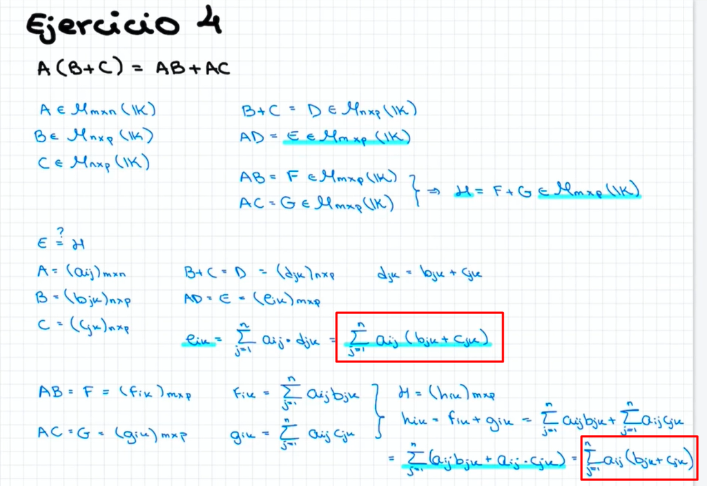

## 4.7 Elemento neutro del producto o elemento unidad

Elemento neutro del producto o elemento unidad.
$$AI_n = A\qquad I_nB = B$$

Sean $A\in\mathcal{M}_{m\times n}(\mathbb{K})$ y $B\in\mathcal{M}_{n\times p}(\mathbb{K})$.

Se puede realizar el producto $AI_n$ y el resultado será una matriz $m\times n$.

Análogamente, se puede realizar el producto $I_nB$ y el resultado será una matriz $n\times p$.

Además, se puede comprobar que se verifica que
$$AI_n = A\qquad\text{y}\qquad I_nB=B$$

**Ejemplo 20**

$$A = \begin{pmatrix}2&3\\3&2\\-1&0\end{pmatrix}\qquad B=\begin{pmatrix}1&0&3&-1&5\\3&6&-1&-4&2\\3&-2&1&-1&0\end{pmatrix}$$

$$AI_2 = \begin{pmatrix}2&3\\3&2\\-1&0\end{pmatrix}\begin{pmatrix}1&0\\0&1\end{pmatrix} = \begin{pmatrix}2&3\\3&2\\-1&0\end{pmatrix} = A$$

$$I_3B = \begin{pmatrix}1&0&0\\0&1&0\\0&0&1\end{pmatrix}\begin{pmatrix}1&0&3&-1&5\\3&6&-1&-4&2\\3&-2&1&-1&0\end{pmatrix}=\begin{pmatrix}1&0&3&-1&5\\3&6&-1&-4&2\\3&-2&1&-1&0\end{pmatrix}=B$$

**Ejercicio 5**

Considerad las matrices con coeficientes en $\mathbb{R}$:

$$A=\begin{pmatrix}1&0&1\\0&1&0\end{pmatrix}\quad B = \begin{pmatrix}1&-1\\0&1\\-1&0\end{pmatrix}$$

Probar que:

$$AI_3 = A$$
$$I_3B=B$$

**Ejercicio 6**

Escribe paso a paso la demostración de esta propiedad tomando como ejemplo las demostraciones anteriores.

Observación.Nótese que, en particular, para matrices cuadradas $A\in\mathcal{M}_n(\mathbb{K})$, $I_n$ es un elemento neutro del producto, es decir: $AI_n=I_nA=A$ para toda matriz cuadrada $A$ de orden $n$.

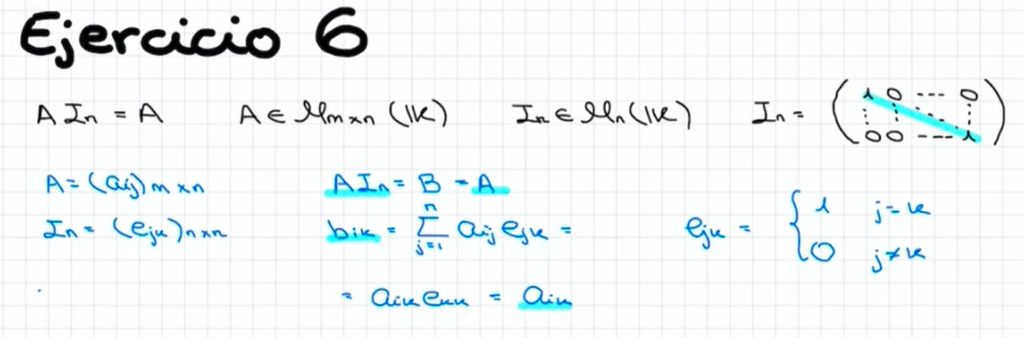

Figure 1: Ejercicio 6.1

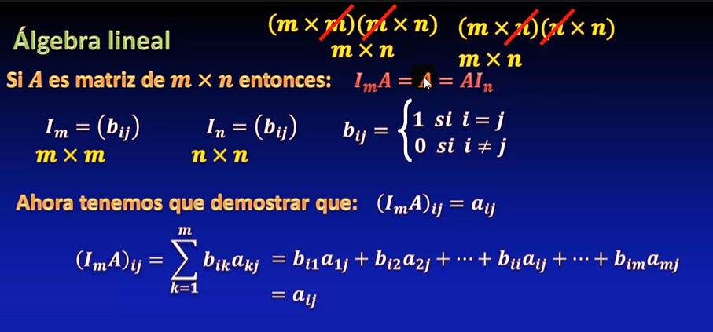

Figure 1: Ejercicio 6.1

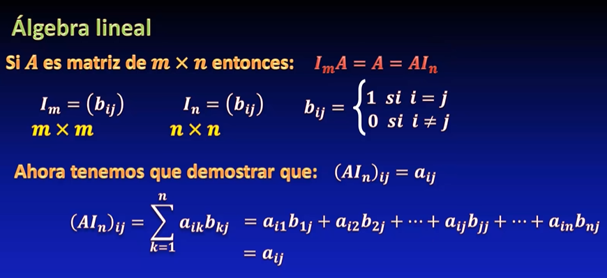

Figure 1: Ejercicio 6.1

**Ejemplo 21**

$$AI_2 = \begin{pmatrix}2&3\\-1&0\end{pmatrix}\begin{pmatrix}1&0\\0&1\end{pmatrix} = \begin{pmatrix}2&3\\-1&0\end{pmatrix} =\begin{pmatrix}1&0\\0&1\end{pmatrix}\begin{pmatrix}2&3\\-1&0\end{pmatrix}=I_2A$$

**Ejercicio 7**

Escribe paso a paso la demostración de esta propiedad tomando como ejemplo las demostraciones anteriores.

## 4.8 Propiedad distributiva del producto por escalares respecto de la sum

Propiedad distributiva del producto por escalares respecto de la suma.
$$\lambda(A+B) = \lambda A+\lambda B,\ \lambda\in\mathbb{K}$$

**Ejercicio 8**

Escribe paso a paso la demostración de esta propiedad tomando como ejemplo las demostraciones anteriores.

**Ejemplo 22**

$$A = \begin{pmatrix}7&1&5\\-1&-2&6\end{pmatrix},\ B=\begin{pmatrix}2&1&0\\-1&-2&-3\end{pmatrix}\in\mathcal{M}_{2\times 3}(\mathbb{R})\qquad \lambda = 3\in\mathbb{R}$$

$$\lambda(A+B)=3\begin{pmatrix}9&2&5\\-2&-4&3\end{pmatrix}=\begin{pmatrix}27&6&15\\-6&-12&9\end{pmatrix}$$
$$\lambda A+\lambda B=\begin{pmatrix}21&3&15\\-3&-6&18\end{pmatrix}+\begin{pmatrix}6&3&0\\-3&-6&-9\end{pmatrix} =\begin{pmatrix}27&6&15\\-6&-12&9\end{pmatrix}$$

## 4.9 Elemento neutro del producto por escalar

Elemento neutro del producto por escalar. $1A=A$

**Ejemplo 23**

$$A = \begin{pmatrix}3&-5&2&0&1\\7&4&1&-3&-2\\6&9&-5&1&0\end{pmatrix}$$

$$1A = \begin{pmatrix}1\cdot3&1\cdot(-5)&1\cdot2&1\cdot0&1\cdot1\\1\cdot7&1\cdot4&1\cdot1&1\cdot(-3)&1\cdot(-2)\\1\cdot6&1\cdot9&1\cdot(-5)&1\cdot1&1\cdot0\end{pmatrix}=\begin{pmatrix}3&-5&2&0&1\\7&4&1&-3&-2\\6&9&-5&1&0\end{pmatrix}=A$$

**Demostración**

Por definición,
$$1A = (1\cdot a_{ij}) = (a_{ij}) = A$$

ya que $a_{ij}\in\mathbb{K}$ y $1$ es el elemento neutro para el producto

## 4.10 Propiedades distributiva del producto por matrices respecto de la suma de escalares

Propiedades distributiva del producto por matrices respecto de la suma de escalares.

$$(\lambda +\mu)A = \lambda A+\mu A,\ \lambda,\mu\in\mathbb{K}$$

**Ejercicio 9**

Escribe paso a paso la demostración de esta propiedad tomando como ejemplo las demostraciones anteriores.

**Ejemplo 24**

$$A =\begin{pmatrix}1&-1\\0&1\end{pmatrix}\qquad \lambda=5,\mu=-7$$

$$(\lambda +\mu)A=-2A = \begin{pmatrix}-2&2\\0&-2\end{pmatrix}$$

$$\lambda A+\mu A=5A+(-7)A=\begin{pmatrix}5&-5\\0&5\end{pmatrix}+\begin{pmatrix}-7&7\\0&-7\end{pmatrix}=\begin{pmatrix}-2&2\\0&-2\end{pmatrix}$$

## 4.11 Propiedad asociativa del producto de escalares por una matriz

Propiedad asociativa del producto de escalares por una matriz.
$$(\lambda\mu)A = \lambda(\mu A), \ \lambda,\mu\in\mathbb{K}$$

**Ejercicio 10**

Escribe paso a paso la demostración de esta propiedad tomando como ejemplo las demostraciones anteriores.

**Ejemplo 25**

$$A =\begin{pmatrix}1&-1\\0&1\end{pmatrix}\qquad \lambda=5,\mu=-7$$
$$(\lambda\mu)A = -35A = \begin{pmatrix}-35&35\\0&-35\end{pmatrix}$$
$$\lambda(\mu A)=5(-7A)=5\begin{pmatrix}-7&7\\0&-7\end{pmatrix}=\begin{pmatrix}-35&35\\0&-35\end{pmatrix}$$

## 4.12 Propiedad asociativa del producto de un escalar por dos matrices

Propiedad asociativa del producto de un escalar por dos matrices.
$$\lambda(AB) = (\lambda A)B,\ \lambda\in\mathbb{K}$$

**Ejemplo 26**
$$A = \begin{pmatrix}2&3\\5&2\end{pmatrix}\qquad B=\begin{pmatrix}1&0&-1\\2&3&5\end{pmatrix}\qquad \lambda=3$$
$$(\lambda A)B=\begin{pmatrix}6&9\\15&6\end{pmatrix}\begin{pmatrix}1&0&-1\\2&3&5\end{pmatrix}=\begin{pmatrix}24&27&39\\27&18&15\end{pmatrix}$$
$$\lambda(AB)=3\cdot\begin{pmatrix}8&9&13\\9&6&5\end{pmatrix}=\begin{pmatrix}24&27&39\\27&18&15\end{pmatrix}$$

**Ejercicio 11**

Escribe paso a paso la demostración de esta propiedad tomando como ejemplo las demostraciones anteriores.

# 5 Excepciones Propiedades

En general, no se cumplen las siguientes propiedades:

## 5.1 Propiedad conmutativa

Propiedad conmutativa. La multiplicación de matrices no es conmutativa.

**Ejemplo 27**
$$A = \begin{pmatrix}0&1\\0&0\end{pmatrix},\ B=\begin{pmatrix}0&0\\1&0\end{pmatrix}\in\mathcal{M}_2(\mathbb{R})$$

$$AB = \begin{pmatrix}1&0\\0&0\end{pmatrix}\ne\begin{pmatrix}0&0\\0&1\end{pmatrix}=BA$$

## 5.2 Ley de simplificación

Ley de simplificación. No se cumple la ley de simplificación en un producto.

**Ejemplo 28**

$$A = \begin{pmatrix}0&1\\0&2\end{pmatrix},\ B=\begin{pmatrix}1&1\\3&4\end{pmatrix},\ C=\begin{pmatrix}2&5\\3&4\end{pmatrix}\in\mathcal{M}_2(\mathbb{R})$$

satisfacen $AB=AC$, pero en cambio $B\ne C$

**Ejercicio 12.** Comprueba que efectivamente $AB=AC$

## 5.3 Divisores de cero

Divisores de cero. Existen divisores de 0, es decir $AB=0\not\Rightarrow A=0\text{ o }B=0$.

**Ejemplo 29**

$$A = \begin{pmatrix}0&3\\0&0\end{pmatrix},\ B=\begin{pmatrix}0&2\\0&0\end{pmatrix}\in\mathcal{M}_2(\mathbb{R})$$

pero en cambio
$$AB=O=\begin{pmatrix}0&0\\0&0\end{pmatrix}$$

## 5.4 Matrices diagonales y triangulares

Proposición. Sean $A,B$ dos matrices cuadradas de orden $n$.

- Si $A,B$ son matrices diagonales, entonces $A$ y $B$ conmutan y la matriz producto $AB=BA$ también es diagonal.
- Si $A,B$ son matrices triangulares superiores (inferiores) entonces el producto $AB$ es también una matriz triangular superior (inferior).

## 5.5 Matrices diagonales y triangulares

**Ejercicio 13.** Dadas
$$A=\begin{pmatrix}1&0&0&0\\0&5&0&0\\0&0&-3&0\\0&0&0&2\end{pmatrix}\qquad B=\begin{pmatrix}-2&0&0&0\\0&6&0&0\\0&0&3&0\\0&0&0&9\end{pmatrix}$$
comprobad que $AB$ y $BA$ son matrices diagonales.

**Ejercicio 14.** Dadas
$$A=\begin{pmatrix}1&-1&4&3\\0&5&-2&1\\0&0&-3&7\\0&0&0&2\end{pmatrix}\qquad B=\begin{pmatrix}-2&1&-1&2\\0&6&0&3\\0&0&3&-5\\0&0&0&-2\end{pmatrix}$$
comprobad que $AB$ y $BA$ son matrices triangulares superiores.

## 5.6 Matriz transpuesta

Transpuesta de una matriz. Sea $A=(a_{ij})_{m\times n}\in\mathcal{M}_{m\times n}(\mathbb{K})$. Se denomina transpuesta de la matriz $A$ y se denota como $A^t$ a la matriz $A^t=(a_{ji})_{n\times m}\in\mathcal{M}_{n\times m}(\mathbb{K})$. Es decir, la matriz obtenida a partir de $A$ intercambiando filas por columnas.

**Ejemplo 30**

La matriz transpuesta de $A = \begin{pmatrix}1&0&3\\2&1&-1\end{pmatrix}$ es
$$A^t=\begin{pmatrix}1&2\\0&1\\3&-1\end{pmatrix}$$

## 5.7 Propiedades matriz transpuesta

Entre las propiedades de las matrices transpuestas destacan las siguientes

Idempotencia. Para toda matriz $A$, $(A^t)^t = A$.

**Ejemplo 31**

Teníamos que lLa matriz transpuesta de $A = \begin{pmatrix}1&0&3\\2&1&-1\end{pmatrix}$ es $A^t=\begin{pmatrix}1&2\\0&1\\3&-1\end{pmatrix}$. Pues la matriz transpuesta de $A^t$ es

$$(A^t)^t = \begin{pmatrix}1&0&3\\2&1&-1\end{pmatrix}=A$$

**Demostración**

$$A\in\mathcal{M}_{m\times n}(\mathbb{K}),\quad A = (a_{ij})\Rightarrow A^t\in\mathcal{M}_{n\times m}(\mathbb{K}),\quad A^t = (a_{ji})\Rightarrow (A^t)^t\in\mathcal{M}_{n\times m}(\mathbb{K}),\quad (A^t)^t = (a_{ij}) = A$$

## 5.8 Propiedades matriz transpuesta

Transpuesta de una suma. Si $A$ y $B$ son matrices del mismo orden $m\times n$, entonces $(A+B)^t = A^t+B^t$. Es decir, la transpuesta de una suma de matrices es la matriz obtenida por la suma de sus respectivas transpuestas. Además, el resultado se puede generalizar a $r$ sumandos y se tiene que si $A_i$ son todas del mismo orden, entonces

$$\left(\sum_{i=1}^r A_i\right)^t=\sum_{i=1}^rA_i^t$$

**Ejercicio 15.** Escribe paso a paso la demostración de esta propiedad

## 5.9 Propiedades matriz transpuesta

**Ejercicio 16.** Comprobar que dadas
$$A = \begin{pmatrix}2&3\\3&2\\-1&0\end{pmatrix}\qquad B=\begin{pmatrix}1&0\\3&6\\3&-2\end{pmatrix}\qquad C = \begin{pmatrix}-2&4\\0&5\\7&2\end{pmatrix}$$
$$(A+B+C)^t=A^t+B^t+C^t$$

## 5.10 Propiedades matriz transpuesta

Transpuesta de un producto. Si $A\in\mathcal{M}_{m\times n}(\mathbb{K})$ y $B\in\mathcal{M}_{n\times p}(\mathbb{K})$, entonces la traspuesta del producto de $A$ por $B$ es el producto de las traspuestas pero con orden cambiado, es decir:
$$(AB)^t=B^tA^t\in\mathcal{M}_{p\times m}(\mathbb{K})$$

**Ejercicio 17.** Probad que $(AB)^t=B^tA^t$ donde
$$A=\begin{pmatrix}1&0&1\\0&1&0\end{pmatrix}\quad B = \begin{pmatrix}1&-1\\0&1\\-1&0\end{pmatrix}$$

**Ejercicio 18.** Escribe paso a paso la demostración de esta propiedad

## 5.11 Matrices cuadradas

Nótese que la transposición, en el caso de matrices cuadradas, es una operación interna

Transposición como operación interna. La transpuesta de una matriz cuadrada $A\in\mathcal{M}_n(\mathbb{K})$ es otra matriz cuadrada $A^t\in\mathcal{M}_n(\mathbb{K})$

**Demostración**

$$A\in\mathcal{M}_n(\mathbb{K})\equiv A\in\mathcal{M}_{n\times n}(\mathbb{K})\Rightarrow A^t\in\mathcal{M}_{n\times n}$$

Por lo tanto, tienen sentido las siguientes definiciones

## 5.12 Matrices cuadradas

Sea $A=(a_{ij})\in\mathcal{M}_n(\mathbb{K})$ una matriz cuadrada

Matriz simétrica. $A$ es simétrica si coincide con su transpuesta. Esto causa la simetría de la matriz respecto a su diagonal.

$$A\text{ simétrica }\Leftrightarrow A=A^t\Leftrightarrow a_{ij}=a_{ji}\ \forall i,j$$

**Ejemplo 32**

$$A = \begin{pmatrix}1&2&3&4\\2&-1&5&6\\3&5&1&7\\4&6&7&-1\end{pmatrix}$$
es una matriz simétrica

**Ejercicio 19.** Calculad $A^t$ y veréis que $A^t=A$.

## 5.13 Matrices cuadradas

Matriz antisimétrica. $A$ es antisimétrica si su transpuesta coincide con su opuesta, lo cual exige que la diagonal esté compuesta únicamente por ceros y que los elementos simétricos sean opuestos entre sí.

$$A\text{ antisimétrica }\Leftrightarrow A^t=-A\Leftrightarrow a_{ij}=-a_{ji}\ \forall i,j$$

**Ejemplo 33**

$$A = \begin{pmatrix}0&2&3&4\\-2&0&5&6\\-3&-5&0&7\\-4&-6&-7&0\end{pmatrix}$$
es una matriz antisimétrica

**Ejercicio 20.** Calculad $A^t$ y veréis que $A^t=-A$.

## 5.14 Matrices cuadradas

Matriz regular. $A$ es invertible o regular si existe otra matriz cuadrada $A^{-1}\in\mathcal{M}_n(\mathbb{K})$ tal que $AA^{-1}=A^{-1}A=I_n$. Cuando existe esta matriz $A^{-1}$ es siempre única, con la propiedad mencionada y se llama matriz inversa de $A$.

Observación. Nótese que no basta con cumplir solo $AA^{-1}=I_n$ (o solo $A^{-1}A=I_n$) ya que el producto no es en general conmutativo. Por tanto, la matriz inversa ha de verificar que los resultados de los dos productos son la matriz identidad.

## 5.15 Matrices cuadradas

**Ejemplo 34**

$A = \begin{pmatrix}1&1&0\\0&1&0\\1&0&1\end{pmatrix}$ es una matriz regular cuya inversa es $A^{-1}=\begin{pmatrix}1&-1&0\\0&1&0\\-1&1&1\end{pmatrix}$

**Ejercicio 21.** Comprobad que efectivamente $AA^{-1}=A^{-1}A=I_3$

## 5.16 Matrices cuadradas

Matriz singular. $A$ es singular si no tiene inversa, es decir, cuando no es regular.

**Ejemplo 35**

$$A = \begin{pmatrix}1&2&3\\4&5&6\\7&8&9\end{pmatrix}$$
es una matriz singular. Más adelante, cuando hablemos de determinantes, veremos el por qué

## 5.17 Matrices cuadradas

Matriz ortogonal. $A$ es ortogonal si es regular y además su inversa coincide con su transpuesta. Dicho de otra manera

$$A\text{ ortogonal }\Leftrightarrow AA^t=A^tA = I_n$$

**Ejemplo 36**

$$A = \frac{1}{3}\begin{pmatrix}2&-2&1\\2&1&-2\\1&2&2\end{pmatrix}$$
es una matriz ortogonal ya que

$$AA^t=\frac{1}{3}\begin{pmatrix}2&-2&1\\2&1&-2\\1&2&2\end{pmatrix}\frac{1}{3}\begin{pmatrix}2&2&1\\-2&1&2\\1&-2&2\end{pmatrix}=\frac{1}{9}\begin{pmatrix}9&0&0\\0&9&0\\0&0&9\end{pmatrix}=I_3$$

**Ejercicio 22.** Comprobad que $A^tA=I_3$

## 5.18 Matrices cuadradas

Proposición. Sean $A,B\in\mathcal{M}_n(\mathbb{K})$. Entonces si $A$ y $B$ son invertibles, también lo es su producto y se cumple:

$$(AB)^{-1}=B^{-1}A^{-1}$$

**Ejercicio 23.** Sean
$$A = \begin{pmatrix}1&2\\7&8\end{pmatrix}\qquad B=\begin{pmatrix}1&3\\-1&0\end{pmatrix}$$
de donde
$$A^{-1} = -\frac{1}{6}\begin{pmatrix}8&-2\\-7&1\end{pmatrix}\qquad B^{-1}=\frac{1}{3}\begin{pmatrix}0&-3\\1&1\end{pmatrix}$$
Comprobad que $B^{-1}A^{-1}=(AB)^{-1}$ donde $(AB)^{-1}=-\frac{1}{18}\begin{pmatrix}21&-3\\1&-1\end{pmatrix}$

## 5.19 Matrices cuadradas

**Demostración**

Para probar $(AB)^{-1}=B^{-1}A^{-1}$, lo que haremos será ver que
$$(AB)(B^{-1}A^{-1}) = (B^{-1}A^{-1})(AB) = I_n$$

Por un lado, por la propiedad asociativa y como $B^{-1}$ es la inversa de $B$, tenemos

$$(AB)(B^{-1}A^{-1}) = A(BB^{-1})A^{-1} = AI_nA^{-1} = AA^{-1}$$
ya que, recordemos, la matriz identidad $I_n$ actúa como elemento neutro del producto de matrices. Ahora, como $A^{-1}$ es la inversa de $A$, se tiene que

$$(AB)(B^{-1}A^{-1}) = AA^{-1} = I_n$$
tal y como queríamos demostrar.

**Ejercicio 24.** Acabar la demostración siguiendo como modelo la parte que se ha llevado a cabo hasta el momento.

# 6 Resumen

## 6.1 Resumen

Las operaciones anteriores conforman el llamado álgebra matricial. Este nombre es adecuado ya que gracias a ellas es posible realizar la manipulación habitual de ecuaciones con matrices igual que se hace con los números reales siempre y cuando se tenga precaución con aquellas propiedades que no se verifican, vistas todas ellas anteriormente.

Por ejemplo, en una ecuación con matrices todo lo que esté sumando pasa al otro término restando y viceversa.

De esta manera, se pueden resolver ecuaciones del tipo: encuentre una matriz $X$ tal que $A+\lambda X=\mu B$ donde $A$ y $B$ son matrices conocidas y $\lambda\ne 0$ y $\mu$ son valores de $\mathbb{K}$ también conocidos. La solución será $X=\frac{1}{\lambda}(\mu B-A)$.

## 6.2 Resumen

Nótese sin embargo que las ecuaciones de la forma $AX=B$ no se pueden manipular de la forma habitual a no ser que la matriz $A$ sea cuadrada e invertible. Entonces se tendrá $X=A^{-1}B$. Nótese que valdría multiplicar a la izquierda por $A^{-1}$ pero no valdría hacerlo a la derecha. Si la ecuación que tiene es de la forma $XA=B$ entonces, si $A$ es invertible, será $X=BA^{-1}$, multiplicando a la derecha por $A^{-1}$.

## 6.3 Resumen

Se pueden calcular también las potencias $n$-ésimas de las matrices de la forma habitual $A^n=A\cdot A\cdot\cdots A$ ($n$ veces). Nótese que el binomio de Newton para calcular $(A+B)^n$ solo se verifica en los casos en que $A$ y $B$ conmuten. Por ejemplo

$$(A+B)^2=A^2+AB+BA+B^2$$

Si $A$ y $B$ conmutan, entonces $(A+B)^2=A^2+2AB+B^2$

# 7 Operaciones elementales. Matrices escalonadas

## 7.1 Matrices escalonadas

Vamos a introducir ahora un tipo especial de matrices triangulares superiores (inferiores), las llamadas matrices escalonadas por filas (por columnas).

Matriz escalonada por filas. Una matriz $A\in\mathcal{M}_{m\times n}(\mathbb{K})$ es escalonada por filas cuando se cumplen simultáneamente las dos condiciones siguientes:

- El primer elemento no nulo de cada fila, denominado pivote, está a la derecha del pivote de la fila superior
- Las filas nulas están en la parte inferior de la matriz.

## 7.2 Matrices escalonadas

**Ejemplo 37**

Estas matrices son escalonadas por filas:

$$\begin{pmatrix}2&1&-1&2\\0&1&-2&1\\0&0&0&2\\0&0&0&0\end{pmatrix}\qquad \begin{pmatrix}3&2&2&5&8\\0&2&-1&9&-3\\0&0&5&3&2\end{pmatrix}$$

## 7.3 Matrices escalonadas

Matriz escalonada reducida. Una matriz $A\in\mathcal{M}_{m\times n}(\mathbb{K})$ es escalonada reducida por filas si es escalonada y además cumple los siguientes requisitos:

- Los pivotes son todos 1’s.
- Todos los elementos que están en la misma columna del pivote son nulos.

## 7.4 Matrices escalonadas

**Ejemplo 38**

Estas matrices son escalonadas reducidas por filas:

$$\begin{pmatrix}1&0&0&2\\0&1&0&1\\0&0&1&-1\\0&0&0&0\end{pmatrix}\qquad \begin{pmatrix}1&0&0&5&8\\0&1&0&7&-3\\0&0&1&10&2\end{pmatrix}$$

## 7.5 Matrices escalonadas

**Ejercicio 25**

- Dad definiciones equivalentes para las matrices escalonadas por columnas y matrices escalonadas reducidas por columnas.
- Poned dos ejemplos de cada tipo de matriz.

## 7.6 Operaciones elementales de una matriz

Operaciones elementales por filas. Sea $A\in\mathcal{M}_{m\times n}(\mathbb{K})$. Las siguientes operaciones se llaman operaciones elementales por filas de la matriz $A$:

- Multiplicar una fila por un $\lambda\in\mathbb{K},\ \lambda\ne 0$.
- Intercambiar dos filas.
- Sumar un múltiplo de una fila a otra.

De manera análoga se pueden definir las operaciones elementales por columnas.

## 7.7 Matrices equivalentes

Matrices equivalentes por filas. Dos matrices $A,B\in\mathcal{M}_{m\times n}(\mathbb{K})$ son equivalentes por filas (por columnas) si una de ellas se puede obtener a partir de la otra mediante un número finito de operaciones elementales por filas (columnas).

Teorema

- Toda matriz es equivalente por filas (columnas) a una matriz escalonada por filas (columnas).
- Toda matriz es equivalente por filas (columnas) a una única matriz escalonada reducida por filas (columnas).

## 7.8 Matrices equivalentes

La demostración la haremos de manera constructiva. Es decir, hallaremos un algoritmo (Método de Gauss) para encontrar la matriz escalonada en este caso.

**DEMOSTRACIÓN**

Sea $A=(a_{ij})\in\mathcal{M}_{m\times n}(\mathbb{K})$, entonces procederemos de la siguiente manera:

1. Si $a_{11}\ne 0$, se divide la primera fila por $a_{11}$ y se obtiene una matriz equivalente en la que $a_{11}=1$. Entonces este nuevo $a_{11}$ será el primer pivote. Ahora, se resta a cada fila $i$ la primera fila multiplicada por $a_{i1}$. Así, la primera resta de elementos de la primera columna será 0 y se pasa al punto 4.
2. Si $a_{11}=0$, se busca el primer $i$ tal que $a_{i1}\ne 0$. Entonces, se intercambian la primera fila y la $i$ obteniendo una matriz equivalente con un nuevo $a_{11}\ne 0$. A partir de aquí, volvemos al punto 1 y repetimos el proceso.
3. Si $a_{i1}=0$ para todo $i=1,\dots,m$, entonces dejamos esta primera columna de ceros y aplicamos el algoritmo del paso 1 a la matriz resultante de eliminar la primera columna.
4. Se repite el proceso a la matriz obtenida de eliminar la primera fila y la primera columna de nuestra matriz.

## 7.9 Matrices equivalentes

Nótese que con el método de la demostración se obtiene la única matriz escalonada equivalente por filas cuyos pivotes son todos unos.

Para obtener la matriz escalonada reducida, si hay algún elemento $a_{ij}$ distinto de cero por encima de algún determinado pivote, se resta a la fila de este elemento (la fila $i$), la fila del pivote multiplicada por $a_{ij}$.

Se repite el paso anterior tantas veces como sea necesario y se llega así a la matriz escalonada reducida equivalente.

## 7.10 Matrices equivalentes

**Ejercicio 26**

Considerad la matriz $A\in\mathcal{M}_{3\times 4}(\mathbb{R})$ dada por

$$A=\begin{pmatrix}1&1&3&5\\2&4&3&-2\\-2&2&-1&3\end{pmatrix}$$

Calculad su matriz escalonada y su escalonada reducida por filas.

## 7.11 Matrices equivalentes

**Ejercicio 27**

Considerad la matriz $A\in\mathcal{M}_{3\times 5}(\mathbb{R})$ dada por

$$A=\begin{pmatrix}0&0&3&5&-1\\1&0&4&-1&2\\2&3&0&-2&3\end{pmatrix}$$

Calculad su matriz escalonada y su escalonada reducida por filas.

# 8 Rango de una matriz

## 8.1 Rango de una matriz

Dada la unicidad de la matriz escalonada reducida, se pueden definir conceptos sobre una matriz $A$ mediante su matriz escalonada reducida por filas (por columnas) equivalente

Rango. Sea $A\in\mathcal{M}_{m\times n}(\mathbb{K})$. Se denomina rango de $A$ y se denota como $\text{rg}(A)$, al número de filas no nulas que tiene su única matriz escalonada (o su escalonada reducida) por filas equivalentes.

**Ejemplo 38**

La matriz
$$A = \begin{pmatrix}1&2&2&5&8\\0&1&-1&7&-3\\0&0&1&10&2\end{pmatrix}$$
tiene rango 3

## 8.2 Rango de una matriz

Teorema. Sea $A\in\mathcal{M}_{m\times n}(\mathbb{K})$. El rango de $A$ coincidirá con el número de columnas no nulas de su única matriz escalonada reducida por columnas equivalente.

En realidad, el número de filas (columnas) no nulas es siempre el mismo en cualquier matriz equivalente por filas (por columnas) a la dada. Por tanto, para calcular el rango de una matriz $A$ bastará con encontrar una matriz $B$ escalonada por filas (columnas) equivalente a $A$ y contar el número de filas (columnas) no nulas de $B$.

## 8.3 Rango de una matriz

**Ejercicio 28**

- Calculad el rango de
  $$A=\begin{pmatrix}1&1&3&5\\2&4&3&-2\\-2&2&-1&3\end{pmatrix}$$
- Calculad el rango de
  $$B = \begin{pmatrix}1&3&1\\0&3&-2\\2&2&3\end{pmatrix}$$

# 9 Cálculo de la matriz inversa

## 9.1 Caracterización de las matrices invertibles

Con las matrices escalonadas y las operaciones elementales, no solo se puede calcular el rango de una matriz sino que también resultan útiles en el cálculo de matrices inversas como veremos a continuación.

El primer aporte que pueden hacer es la caracterización de las matrices invertibles a través de su rango y de su matriz escalonada reducida.

## 9.2 Teorema de caracterización

Teorema. Sea $A$ una matriz cuadrada $A\in\mathcal{M}_n(\mathbb{K})$. Entonces son equivalentes:

- $A$ es invertible
- $rg(A)=n$
- La matriz escalonada reducida por filas (por columnas) equivalente a $A$ es la matriz identidad $I_n$

## 9.3 Teorema de caracterización

Además, la tercera equivalencia aporta un método para calcular la matriz inversa de una matriz invertible $A\in\mathcal{M}_n(\mathbb{K})$: Este consiste en escribir la matriz identidad $I_n$ a la derecha de la matriz (escrito de forma abreviada $(A|I_n)$) y a través de transformaciones elementales por filas (o por columnas), calcular la matriz escalonada reducida que será de la forma $(I_n|B)$. La matriz $B$ resultante es precisamente la matriz inversa de $A$, es decir $A^{-1}=B$.

## 9.4 Cálculo de la matriz inversa

**Ejercicio 29**

Sea $A$ la matriz cuadrada $A\in\mathcal{M}_n(\mathbb{K})$ dada por

$$\begin{pmatrix}1&3&-1\\0&2&3\\ -1&0&2\end{pmatrix}$$

Razonad si $A$ es invertible y, si lo es, calculad su inversa.

# 10 Aplicaciones de las matrices

## 10.1 Aplicaciones de las matrices

- Álgebra lineal y geometría
- Modelos lineales en ingeniería y economía
- Ecuaciones en diferencias
- Tratamiento de imágenes y diseño asistido por ordenador
- Matrices booleanas, grafos y relaciones
- Matrices estocásticas y estadística
- Ecuaciones diferenciales y sistemas dinámicos